# Tarea 1 Minería de Datos

Shanthal Chavarría

8/11/2020

2. Dado x = (3,−5,31,−1,−9,10,0,18) y dado y = (1,1,−3,1,−99,−10,10,−7) realice lo siguiente:

Introduzca x y y como vectores en R.

```r
x <- c(3,-5,31,-1,-9,10,0,18)
y <- c(1,1,-3,1,-99,-10,10,-7)
```

Calcule la media, la varianza, la raíz cuadrada y la desviación estándar de y.

```r
mean(y)
```

```
## [1] -13.25
```

```r
var(y)
```

```
## [1] 1236.786
```

```r
sqrt(abs(y))
```

```
## [1] 1.000000 1.000000 1.732051 1.000000 9.949874 3.162278 3.162278 2.645751
```

```r
sd(y)
```

```
## [1] 35.16796
```

Calcule la media, la varianza, la ra ́ız cuadrada y la desviacio ́n esta ́ndar de x.

```r
mean(x)
```

```
## [1] 5.875
```

```r
var(x)
```

```
## [1] 174.9821
```

```r
sqrt(abs(x))
```

```
## [1] 1.732051 2.236068 5.567764 1.000000 3.000000 3.162278 0.000000 4.242641
```

```r
sd(x)
```

```
## [1] 13.22808
```

Calcule la correlaci ́on entre x y y.

```r
cor(x,y)
```

```
## [1] 0.3659679
```

Escriba un comando en R para extraer las entradas 2 a la 7 de x.

```r
x[2:7]
```

```
## [1] -5 31 -1 -9 10  0
```

Escriba un comando en R para extraer las entradas de y excepto la 2 y la 7.

```r
y[-c(2,7)]
```

```
## [1]   1  -3   1 -99 -10  -7
```

Escriba un comando en R para extraer las entradas de y menores a -3 o mayores a 10.

```r
y[ 10 < y | y < -3 ]
```

```
## [1] -99 -10  -7
```

Escriba un comando en R para extraer las entradas de x mayores a 0 y que sean nu ́meros pares.

```r
x[x%%2 == 0 & x > 0]
```

```
## [1] 10 18
```

3. Introduzca en R la siguiente matriz a 4 × 3 usando: A = matrix(c(1,2,3,4,5,6,7,8,9,10,11,12),nrow=4,“byrow”=“true”) Luego, obtenga algunos elementos de la matriz de la siguiente manera: A[1,1:3], A[1:4,2], A[3,3], A[11], A[20], A[5,4], A[1,1,1] y explique qu ́e pasa en cada caso.

```r
A = matrix(c(1,2,3,4,5,6,7,8,9,10,11,12),nrow=4,"byrow"="true")

A[1,1:3] #muestra los primeros tres elementos de la fila uno

A[1:4,2] #de las cuatro filas muestra el segundo elemento

A[3,3] # elemento de la tercer fila y tercer columna

A[11] #el undecimo elemento contando de arriba hacia abajo

A[20] #el vigésimo elemento no existe en la tabla

A[5,4] #elemento de la quinta fila y cuarta columna no existe

A[1,1,1] #el tercer indice está de más
```

[output not shown]

4. Investigue para qu ́e sirven los comandos de R as.matrix(…) y as.data.frame(…), expli- que y d ́e un ejemplo de cada uno.

as.matrix() cambiar el argumento ingresado en una matriz

```r
as.matrix(x)
```

```
##      [,1]
## [1,]    3
## [2,]   -5
## [3,]   31
## [4,]   -1
## [5,]   -9
## [6,]   10
## [7,]    0
## [8,]   18
```

as.data.frame() cambia el argumento a dataframe.

```r
as.data.frame(y)
```

| y |
| --- |
| 1 |
| 1 |
| -3 |
| 1 |
| -99 |
| -10 |
| 10 |
| -7 |

5. Introduzca usando código R (no archivos) en un DataFrame la siguiente tabla de datos:

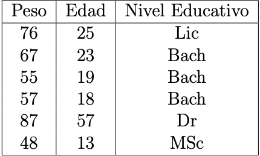

| Peso | Edad | Nivel_Educativo |
| --- | --- | --- |
| 76 | 25 | Lic |
| 67 | 23 | Bach |
| 55 | 19 | Bach |
| 57 | 18 | Bach |
| 87 | 57 | Dr |
| 48 | 13 | MSc |

6. En muchas ocasiones nos interesa hacer referencia a determinadas partes o componentes de un vector. Defina el vector x = (2, −5, 4, 6, −2, 8), luego a partir de este vector defina instrucciones en R para generar los siguientes vectores:
- y = (2, 4, 6, 8), así definido y es el vector formado por las componentes positivas de x.

```r
x <- c(2, -5, 4, 6, -2, 8)
y <- x[x>0]

y
```

```
## [1] 2 4 6 8
```

- z = (−5, −2), así definido z es el vector formado por las componentes negativas de x.

```r
z <- x[x<0]
z
```

```
## [1] -5 -2
```

- v = (−5, 4, 6, −2, 8), así definido v es el vector x eliminada la primera componente.

```r
v <- x[-1]
v
```

```
## [1] -5  4  6 -2  8
```

w = (2, 4, −2). así definido w es el vector x tomando las componentes impares.

```r
w <- x[c(T,F)]

w
```

```
## [1]  2  4 -2
```

7. Queremos representar gráficamente la funci ́on coseno en el intervalo [0, 2π]. Para esto creamos el vector x de la siguiente forma x<-seq(0,2*pi,length=100). ¿Cu ́al es la diferencia entre las gra ́ficas obtenidas por comandos plot?

En el primer gráfico el eje x y el color no es especifican por lo que toman valores predeterminados, en el segundo gráfico la escala del eje x es x y su color es rojo.

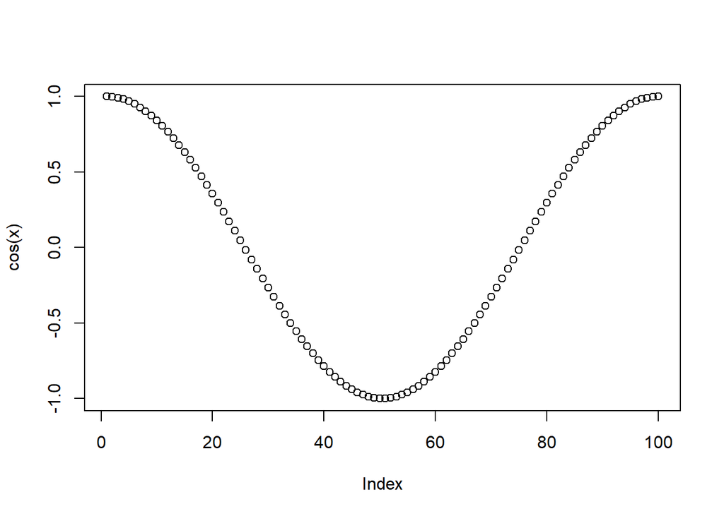

```r
x<-seq(0,2*pi,length=100)
plot(cos(x))
```

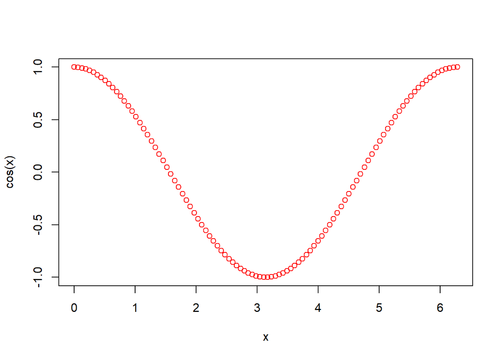

```r
plot(x,cos(x),col="red")
```

8. Para tabla de Datos que viene en el archivo DJTable.csv el cual contiene los valores de las acciones de las principales empresas de Estados Unidos en el an ̃o 2010, usando el comando plot de R, grafique (en un mismo gra ́fico) las series de valores de las acciones de las empresas CSCO (Cisco), IBM, INTC (Intel) y MSFT (Microsoft).

```r
library(readr)
library(lubridate)
library(dplyr)
DJTable <- read_delim("DatosTarea1/DJTable.csv",
    ";", escape_double = FALSE, trim_ws = TRUE)
names(DJTable)[1] <- "FECHA"

DJTable <- DJTable %>%
  mutate(FECHA = as.Date(FECHA,"%d/%m/%Y"))

str(DJTable)
```

```
## Classes 'spec_tbl_df', 'tbl_df', 'tbl' and 'data.frame': 252 obs. of  31 variables:
##  $ FECHA: Date, format: "2010-12-31" "2010-12-30" ...
##  $ AA   : num  15.4 15.2 15.1 15.2 15.2 ...
##  $ AXP  : num  42.9 42.5 42.9 42.8 43 ...
##  $ BA   : num  65.3 65 65 64.9 64.8 ...
##  $ BAC  : num  13.3 13.3 13.3 13.3 13.3 ...
##  $ CAT  : num  93.7 93.9 93.8 93.7 94.1 ...
##  $ CSCO : num  20.2 20.2 20.2 20.4 20.2 ...
##  $ CVX  : num  91.2 91.6 91.4 91.2 90.1 ...
##  $ DD   : num  49.9 49.7 50 49.8 49.6 ...
##  $ DIS  : num  37.5 37.5 37.6 37.4 37.5 ...
##  $ GE   : num  18.3 18.2 18.3 18.3 18.2 ...
##  $ HD   : num  35.1 34.9 34.9 35.1 35.2 ...
##  $ HPQ  : num  42.1 42.3 42.3 42.2 41.8 ...
##  $ IBM  : num  147 147 147 146 145 ...
```

[output cut: 17 more lines]

[figure not shown]

```r
plot(x = DJTable$FECHA, y = DJTable$CSCO,type = "l",col = "red",
   main = "Stock chart", ylab = "", xlab = "", ylim = c(0,250))
lines(x= DJTable$FECHA, y= DJTable$IBM, type = "l", col = "green")
lines(x = DJTable$FECHA, y= DJTable$INTC, type = "l", col = "blue")
lines(x= DJTable$FECHA, y = DJTable$MSFT, type = "l", col = "purple")
legend("topright", c("IBM","MSFT","CSCO","INTC"), fill = c("red","green","blue","purple"), title = "Empresas: ")
```

9. Repita el ejercicio anterior usando funciones del paquete ggplot2.

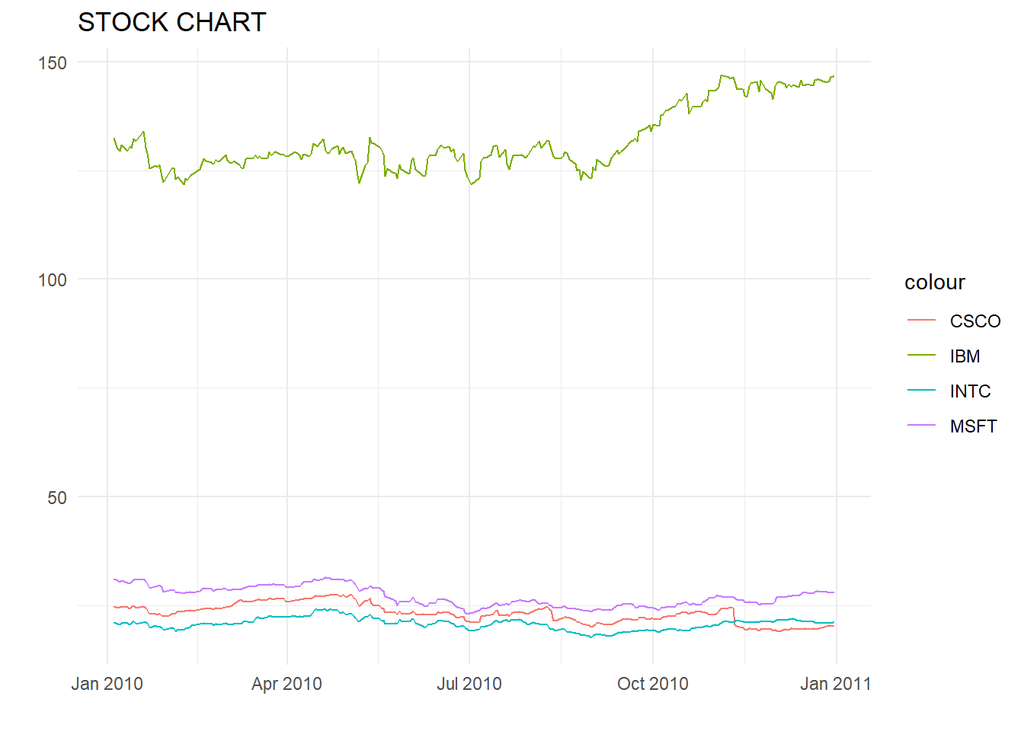

```r
library(ggplot2)

DJTable %>%
  ggplot(mapping = aes(x= FECHA)) +
  geom_line(mapping = aes(y= CSCO, color = "CSCO"))+
  geom_line(mapping= aes(y=IBM, color = "IBM")) +
  geom_line(mapping =  aes(y=INTC, color = "INTC"))+
  geom_line(mapping =  aes(y = MSFT, color = "MSFT"))+
  labs(x = "", y = "", title = "STOCK CHART")+
  theme_minimal()
```

10. Cargue en un DataFrame el archivo EjemploAlgoritmosRecomendacion.csv y haga lo siguiente:

Calcule la dimensión de la Tabla de Datos.

```r
Datos <- read.table("DatosTarea1/EjemploAlgoritmosRecomendacion.csv",
                    header=TRUE, sep=";",dec=",",row.names=1)

dim(Datos)
```

```
## [1] 100   9
```

Despliegue las primeras 2 columnas de la tabla de datos.

```r
Datos[,1:2]
```

|  | VelocidadEntrega | Precio |
| --- | --- | --- |
| Adam | 2.05 | 0.30 |
| Anna | 0.90 | 1.50 |
| Bernard | 1.70 | 2.60 |
| Edward | 1.35 | 0.50 |
| Emilia | 3.00 | 0.45 |
| Fabian | 0.95 | 1.65 |
| Philip | 2.30 | 1.20 |
| Frank | 0.65 | 2.10 |
| Xavier | 2.75 | 0.80 |
| Gabriel | 2.00 | 1.75 |

[output cut: 90 more lines]

Ejecute un “summary” y un “str” de los datos.

```r
summary(Datos)
```

```
##  VelocidadEntrega     Precio        Durabilidad    ImagenProducto
##  Min.   :0.000    Min.   :0.1000   Min.   :2.500   Min.   :1.250
##  1st Qu.:1.250    1st Qu.:0.7375   1st Qu.:3.350   1st Qu.:2.288
##  Median :1.700    Median :1.0750   Median :4.025   Median :2.500
##  Mean   :1.758    Mean   :1.1820   Mean   :3.947   Mean   :2.624
##  3rd Qu.:2.300    3rd Qu.:1.6125   3rd Qu.:4.550   3rd Qu.:3.000
##  Max.   :3.050    Max.   :2.7000   Max.   :5.000   Max.   :4.100
##  ValorEducativo  ServicioRetorno TamanoPaquete   Calidad.Producto
##  Min.   :0.700   Min.   :1.100   Min.   :1.850   Min.   :1.600
##  1st Qu.:2.400   1st Qu.:2.200   1st Qu.:2.900   1st Qu.:2.050
##  Median :3.000   Median :2.600   Median :3.575   Median :2.425
##  Mean   :2.916   Mean   :2.665   Mean   :3.486   Mean   :2.385
##  3rd Qu.:3.425   3rd Qu.:3.000   3rd Qu.:4.162   3rd Qu.:2.700
##  Max.   :4.600   Max.   :4.600   Max.   :5.000   Max.   :3.400
##  NumeroEstrellas
##  Min.   :1.000
##  1st Qu.:2.400
##  Median :3.150
##  Mean   :3.110
##  3rd Qu.:3.825
##  Max.   :5.000
```

```r
str(Datos)
```

```
## 'data.frame':    100 obs. of  9 variables:
##  $ VelocidadEntrega: num  2.05 0.9 1.7 1.35 3 0.95 2.3 0.65 2.75 2 ...
##  $ Precio          : num  0.3 1.5 2.6 0.5 0.45 1.65 1.2 2.1 0.8 1.75 ...
##  $ Durabilidad     : num  3.45 3.15 2.85 3.55 4.8 3.95 4.75 3.1 4.7 3.25 ...
##  $ ImagenProducto  : num  2.35 3.3 3 2.95 3.9 2.4 3.3 2.55 2.35 3 ...
##  $ ValorEducativo  : num  2.4 2.5 4.3 1.8 3.4 2.6 3.5 2.8 3.5 3.7 ...
##  $ ServicioRetorno : num  2.3 4 2.7 2.3 4.6 1.9 4.5 2.2 3 3.2 ...
##  $ TamanoPaquete   : num  2.6 4.2 4.1 3.9 2.25 4.85 3.8 3.45 3.8 4.35 ...
##  $ Calidad.Producto: num  2.1 2.15 2.6 1.95 3.4 2.2 2.9 2.15 2.7 2.7 ...
##  $ NumeroEstrellas : num  1.7 2.8 3.3 1.7 4.3 3 3.1 2.9 4.8 3.9 ...
```

Calcule la Media y la Desviación Estándar para todas las variables cualesquiera.

```r
lapply(Datos,sd) #desviación estandar
```

```
## $VelocidadEntrega
## [1] 0.6603632
##
## $Precio
## [1] 0.5978294
##
## $Durabilidad
## [1] 0.693251
##
## $ImagenProducto
## [1] 0.5657069
##
## $ValorEducativo
## [1] 0.7512575
##
## $ServicioRetorno
## [1] 0.7708548
##
## $TamanoPaquete
## [1] 0.7926205
##
## $Calidad.Producto
## [1] 0.4277788
##
## $NumeroEstrellas
## [1] 0.898877
```

```r
summary(Datos)[4,] # Media
```

```
##   VelocidadEntrega             Precio        Durabilidad
##  "Mean   :1.758  " "Mean   :1.1820  "  "Mean   :3.947  "
##     ImagenProducto     ValorEducativo    ServicioRetorno
##  "Mean   :2.624  "  "Mean   :2.916  "  "Mean   :2.665  "
##      TamanoPaquete   Calidad.Producto    NumeroEstrellas
##  "Mean   :3.486  "  "Mean   :2.385  "  "Mean   :3.110  "
```

Ahora repita los ítems anteriores pero leyendo el archivo como sigue:

Datos <- read.table(’EjemploAlgoritmosRecomendacion.csv’, header=TRUE, sep=’;’,dec=’.’,row.names=1)

Explique porqué todo da mal o genera error.

```r
Datos <- read.table("DatosTarea1/EjemploAlgoritmosRecomendacion.csv",
header=TRUE, sep=";",dec=".",row.names=1)


dim(Datos)

Datos[,1:2]

summary(Datos) #nalgunas funciones no pueden calcular debido a que las columans fueron leídas como chr y no como númericas.
str(Datos)

lapply(Datos, sd) #de nuevo las columnas son de tip chr y no númericas
summary(Datos)[4,] #la función no retornó el calculo de la media debido al tipo de columnas
```

[output not shown]

11. Usando el archivo de datos EjemploAlgoritmosRecomendacion.csv realice lo siguiente:
1. Grafique usando los comandos plot y qplot en el plano XY las variables Entrega vs Precio.

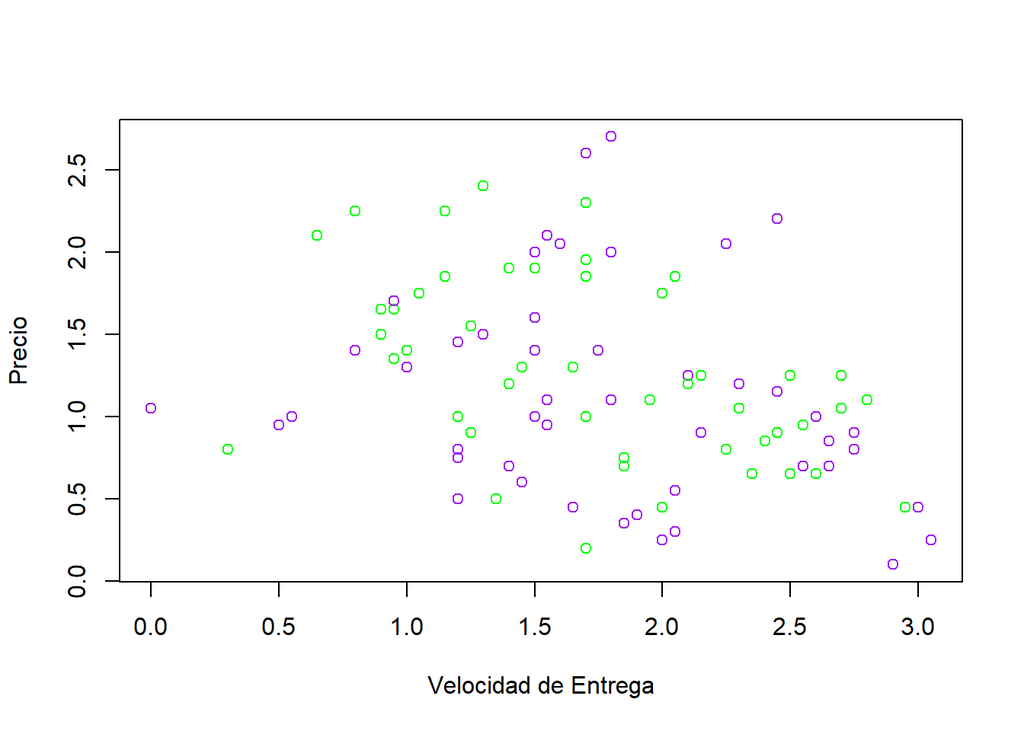

```r
EjemploAlgoritmosRecomendacion <- read.table("DatosTarea1/EjemploAlgoritmosRecomendacion.csv",
    ";", dec = ",", header = TRUE, row.names = 1)


plot(EjemploAlgoritmosRecomendacion$VelocidadEntrega, EjemploAlgoritmosRecomendacion$Precio, col = c("purple","green"),
   main = "", ylab = "Precio", xlab = "Velocidad de Entrega")
```

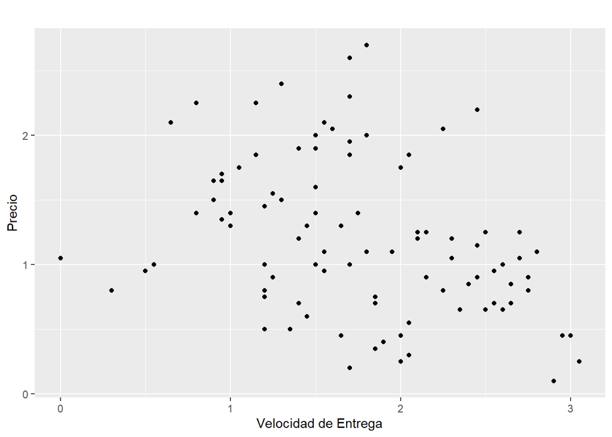

```r
qplot(EjemploAlgoritmosRecomendacion$VelocidadEntrega,EjemploAlgoritmosRecomendacion$Precio,
   main = "", ylab = "Precio", xlab = "Velocidad de Entrega")
```

2. Grafique usando comando scatterplot3d en 3 dimensiones las variables Entrega, Precio y Durabilidad.

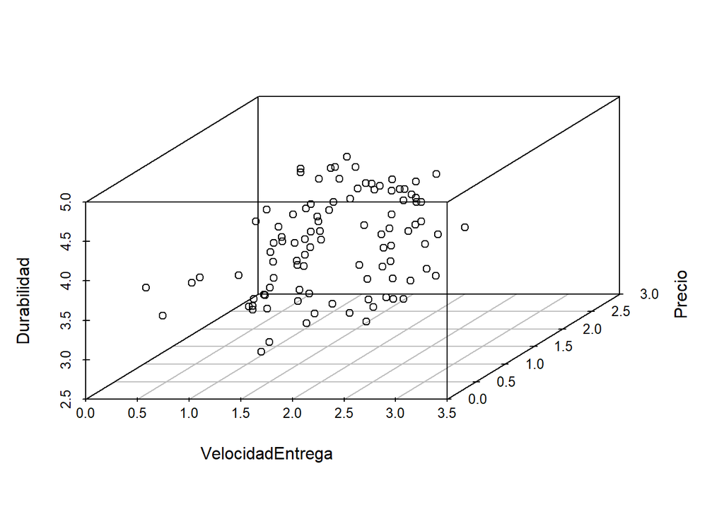

```r
library(scatterplot3d)

scatterplot3d(EjemploAlgoritmosRecomendacion[,1:3])
```

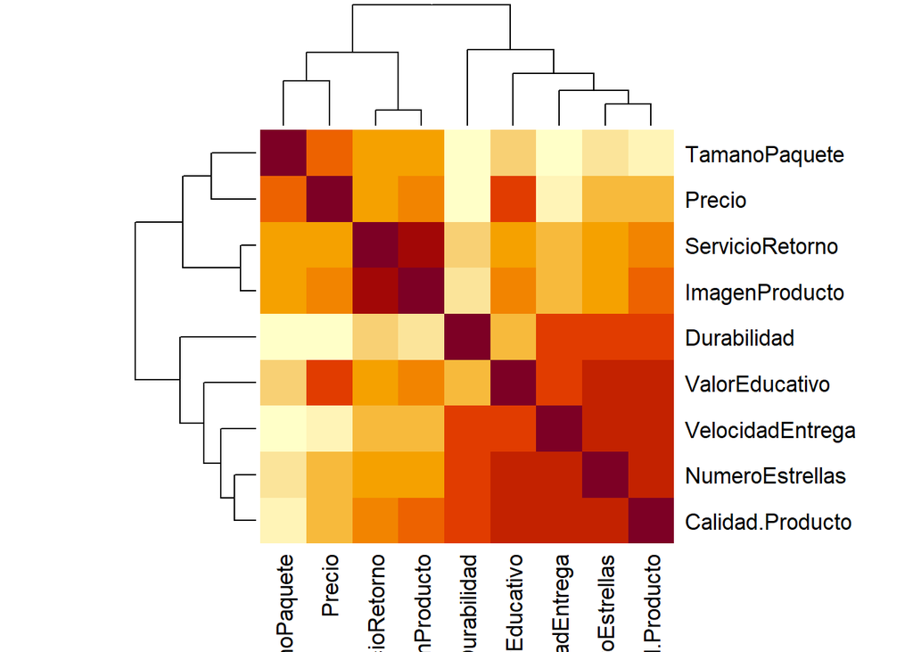

```r
library(corrplot)
library(PerformanceAnalytics)
correlaciones <- cor(EjemploAlgoritmosRecomendacion)

heatmap(x = correlaciones, symm = TRUE)
```

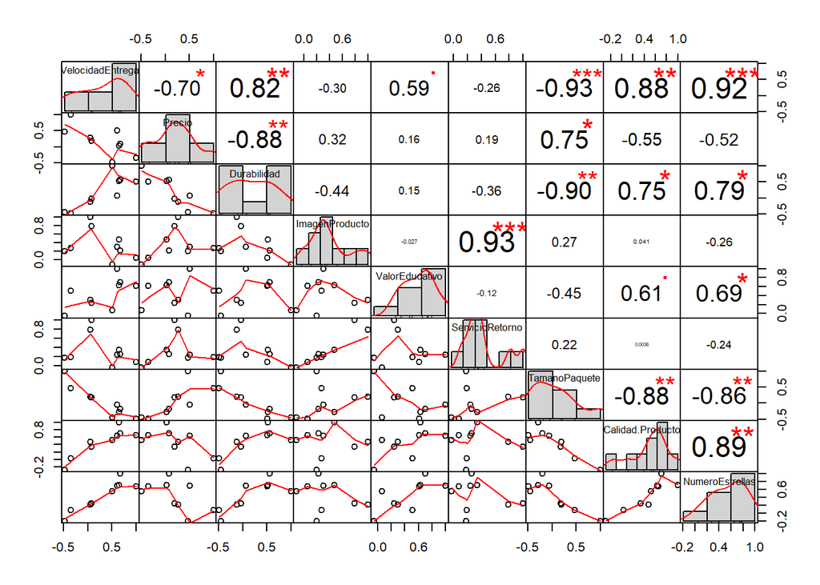

```r
chart.Correlation(correlaciones, histogram=TRUE, pch=19)
```

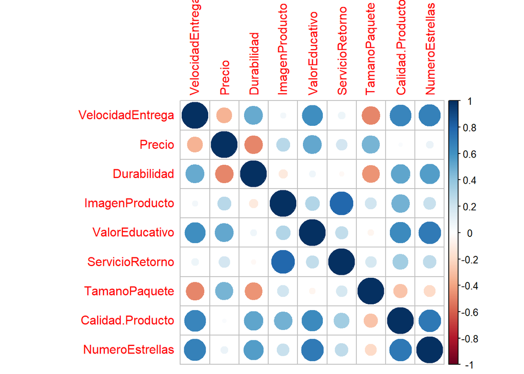

```r
corrplot(correlaciones)
```

4. Usando el comando Boxplot encuentre los datos atípicos de la tabla de datos Ejemplo AlgoritmosRecomendacion.csv.

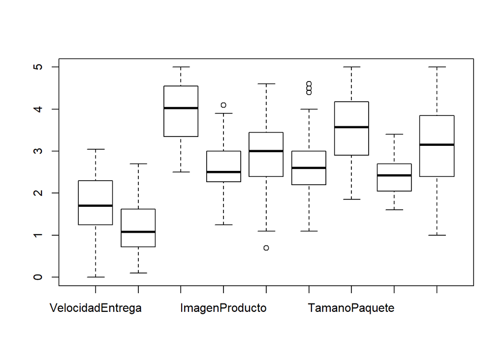

```r
boxplot(EjemploAlgoritmosRecomendacion)
```

12. Cargue la tabla de datos que está en el archivo SAheartv.csv haga lo siguiente:

```r
SAheart <- read.table("DatosTarea1/SAheart.csv",
    ";", dec = ".", header = TRUE)
```

Calcule la dimensión de la Tabla de Datos.

```r
dim(SAheart) #462 filas y 10 columnas
```

```
## [1] 462  10
```

Despliegue las primeras 3 columnas de la tabla de datos.

```r
SAheart[,1:3]
```

| sbp | tobacco | ldl |
| --- | --- | --- |
| 160 | 12.00 | 5.73 |
| 144 | 0.01 | 4.41 |
| 118 | 0.08 | 3.48 |
| 170 | 7.50 | 6.41 |
| 134 | 13.60 | 3.50 |
| 132 | 6.20 | 6.47 |
| 142 | 4.05 | 3.38 |
| 114 | 4.08 | 4.59 |
| 114 | 0.00 | 3.83 |
| 132 | 0.00 | 5.80 |

[output cut: 452 more lines]

Ejecute un summary y un str de los datos.

```r
str(SAheart)
```

```
## 'data.frame':    462 obs. of  10 variables:
##  $ sbp      : int  160 144 118 170 134 132 142 114 114 132 ...
##  $ tobacco  : num  12 0.01 0.08 7.5 13.6 6.2 4.05 4.08 0 0 ...
##  $ ldl      : num  5.73 4.41 3.48 6.41 3.5 6.47 3.38 4.59 3.83 5.8 ...
##  $ adiposity: num  23.1 28.6 32.3 38 27.8 ...
##  $ famhist  : Factor w/ 2 levels "Absent","Present": 2 1 2 2 2 2 1 2 2 2 ...
##  $ typea    : int  49 55 52 51 60 62 59 62 49 69 ...
##  $ obesity  : num  25.3 28.9 29.1 32 26 ...
##  $ alcohol  : num  97.2 2.06 3.81 24.26 57.34 ...
##  $ age      : int  52 63 46 58 49 45 38 58 29 53 ...
##  $ chd      : Factor w/ 2 levels "No","Si": 2 2 1 2 2 1 1 2 1 2 ...
```

```r
summary(SAheart)
```

```
##       sbp           tobacco             ldl           adiposity
##  Min.   :101.0   Min.   : 0.0000   Min.   : 0.980   Min.   : 6.74
##  1st Qu.:124.0   1st Qu.: 0.0525   1st Qu.: 3.283   1st Qu.:19.77
##  Median :134.0   Median : 2.0000   Median : 4.340   Median :26.11
##  Mean   :138.3   Mean   : 3.6356   Mean   : 4.740   Mean   :25.41
##  3rd Qu.:148.0   3rd Qu.: 5.5000   3rd Qu.: 5.790   3rd Qu.:31.23
##  Max.   :218.0   Max.   :31.2000   Max.   :15.330   Max.   :42.49
##     famhist        typea         obesity         alcohol
##  Absent :270   Min.   :13.0   Min.   :14.70   Min.   :  0.00
##  Present:192   1st Qu.:47.0   1st Qu.:22.98   1st Qu.:  0.51
##                Median :53.0   Median :25.80   Median :  7.51
##                Mean   :53.1   Mean   :26.04   Mean   : 17.04
##                3rd Qu.:60.0   3rd Qu.:28.50   3rd Qu.: 23.89
##                Max.   :78.0   Max.   :46.58   Max.   :147.19
##       age        chd
##  Min.   :15.00   No:302
##  1st Qu.:31.00   Si:160
##  Median :45.00
##  Mean   :42.82
##  3rd Qu.:55.00
##  Max.   :64.00
```

Usando el comando cor de R calcule la correlación entre las variables tobacco y alcohol.

```r
cor(SAheart$tobacco, SAheart$alcohol)
```

```
## [1] 0.2008134
```

Calcule la suma de las columnas con variables cuantitativas (numéricas).

```r
colSums(SAheart[,-c(5,10)])
```

```
##       sbp   tobacco       ldl adiposity     typea   obesity   alcohol
##  63907.00   1679.67   2190.03  11737.91  24534.00  12032.38   7874.51
##       age
##  19781.00
```

Calcule para todas las variables cuantitativas presentes en el archivo SAheart.csv: El mínimo, el máximo, la media, la mediana y para la variables chd determine la cantidad de Si y de No.

```r
summary(SAheart[,-c(5,10)])[c(1,6,4,3),]
```

```
##       sbp           tobacco             ldl           adiposity
##  Min.   :101.0   Min.   : 0.0000   Min.   : 0.980   Min.   : 6.74
##  Max.   :218.0   Max.   :31.2000   Max.   :15.330   Max.   :42.49
##  Mean   :138.3   Mean   : 3.6356   Mean   : 4.740   Mean   :25.41
##  Median :134.0   Median : 2.0000   Median : 4.340   Median :26.11
##      typea         obesity         alcohol            age
##  Min.   :13.0   Min.   :14.70   Min.   :  0.00   Min.   :15.00
##  Max.   :78.0   Max.   :46.58   Max.   :147.19   Max.   :64.00
##  Mean   :53.1   Mean   :26.04   Mean   : 17.04   Mean   :42.82
##  Median :53.0   Median :25.80   Median :  7.51   Median :45.00
```

```r
SAheart%>%
  count(chd, name = "Cantidad")
```

| chd | Cantidad |
| --- | --- |
| No | 302 |
| Si | 160 |

```r
SAheart%>%
  count(famhist, name = "Cantidad")
```

| famhist | Cantidad |
| --- | --- |
| Absent | 270 |
| Present | 192 |

13. Programe en R una función que genera 200 números al azar entre 1 y 500 y luego calcula cuántos están entre el 50 y 450, ambos inclusive.

```r
numeros <- as.numeric(sample(1:500, 200))

numeros[numeros > 50  & numeros < 450]
```

```
##   [1] 346 363 221 374 258 407 353 109  74 326 234 312 413 134 178 204 270
##  [18]  57 441 257 202 114 319 135 389 137 262 167  66  83 164 170  54 250
##  [35] 136  93 265 328 210 140 449 212 293 179 275  62 427  94 350 171 255
##  [52] 431 357 186 393  84 169 208 388 213 305 280  60 446 146  75 436 282
##  [69] 317 149 308 309 214 192 242 339 395 340 416 409 271 438 224 373 166
##  [86] 442 123 437 160 244 294 128 279 147 155 322  97 272 445 398 226 334
## [103] 185 428 422 365 177 287 197 362 127 325 121 366  85 207 424 229  80
## [120] 448 370 367 311 236 330 331 281 110 411  86 100 290 372 397 152 414
## [137] 348  55 122 276 118 222 291 349 268  56 289 405 104  71 404 429 223
## [154] 112 335 141  81 238 211 131
```

14. Desarrolle una función que calcula el costo de una llamada telefónica que ha durado t minutos sabiendo que si t < 1 el costo es de 0,4 dólares, mientras que para duraciones superiores el costo es de 0,4 + (t − 1)/4 dólares, la función debe recibir el valor de t.

```r
llamadaTelefonica <- function(t){
  costo <- 0

  if (t <= 0){
    costo <- costo
    } else if  (t > 0 & t < 1){
      costo <- 0.4
      } else{
        costo <- 0.4 + (t-1)/4
        }
  return(costo)
  }

llamadaTelefonica(4.5)
```

```
## [1] 1.275
```

15. Desarrolle una función que recibe una matriz cuadrada A de tamaño n × n y calcula su traza, es decir, la suma de los elementos de la diagonal. Por ejemplo, la traza de la siguiente matriz es 10

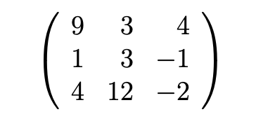

```r
knitr::include_graphics("Captura de Pantalla 2020-08-14 a la(s) 10.54.44.png")
```

```r
B <- matrix(data = c(9,3,4,1,3,-1,4,12,-2), nrow=3, ncol=3)
B
```

```
##      [,1] [,2] [,3]
## [1,]    9    1    4
## [2,]    3    3   12
## [3,]    4   -1   -2
```

```r
trazaMatriz <- function(x){
  return(sum(diag(x)))
}

trazaMatriz(B)
```

```
## [1] 10
```

16. Escribir una función que genere los n primeros términos de la serie de Fibonacci.

```r
Fibonacci <- function(n){
  serie <- 0
  for (i in 0:n){
    serie[i+1] <- (((1+sqrt(5))/2)^i - ((1-sqrt(5))/2)^i)/sqrt(5)
  }
  return(serie)
}

Fibonacci(20)
```

```
##  [1]    0    1    1    2    3    5    8   13   21   34   55   89  144  233
## [15]  377  610  987 1597 2584 4181 6765
```

17. Escriba una función que retorne cúal es el mayor número entero cuyo cuadrado no excede de x donde x es un número real que se recibe como parámetro, utilizando while.

```r
cuadrado <- function(x){
  i <- 1
  while(i^2 < x){
    i <- i+1
  }

  return(i-1)
}

cuadrado(500)
```

```
## [1] 22
```

# 18.

## Crear un Data Frame con diez alumnos con su edad, año de nacimiento y número de teléfono. Deberá aparecer el nombre de la columna (edad, año de nacimiento, teléfono) y el nombre de la fila, que será el nombre del alumno al que corresponden los datos.

```r
alumnos <- data.frame(edad = c(8,8,9,9,9,8,9,9,10,8),
           annoNac = c(2011,2011,2011,2011,2011,2011,2011,2011,2010,2011),
           numTelef =  as.vector(sample(80000000:89999999,10)))

nombres <- c("Maria","Jose","Ana", "Paula", "Cristina", "Guillermo", "Carlos", "Jason", "Jocelyn", "Luis" )

rownames(alumnos) <- nombres

alumnos
```

|  | edad | annoNac | numTelef |
| --- | --- | --- | --- |
| Maria | 8 | 2011 | 82632125 |
| Jose | 8 | 2011 | 80718691 |
| Ana | 9 | 2011 | 86029819 |
| Paula | 9 | 2011 | 84838995 |
| Cristina | 9 | 2011 | 82407603 |
| Guillermo | 8 | 2011 | 85462640 |
| Carlos | 9 | 2011 | 82422842 |
| Jason | 9 | 2011 | 87358095 |
| Jocelyn | 10 | 2010 | 86356047 |
| Luis | 8 | 2011 | 84691338 |

19. Programe funciones en R para calcular:

El número de permutaciones con repetición de r objetos tomados de n.

```r
permutRep <- function(n,r){
  return(n^r)
}

permutRep(3,1)
```

```
## [1] 3
```

El número de permutaciones sin repetición, o arreglo, de r objetos tomados de n.

```r
permutNoRep <- function(r,n){
  factorial(n)/factorial(n-r)
}

permutNoRep(3,16)
```

```
## [1] 3360
```

El número de permutaciones con repetición de n objetos, de los cuales solo k son distintos.

```r
PermutacEspecial <-function(n,k,v){


  if(sum(v) == n & length(v) == k){

    producto <- factorial(n)


    for (i in 1:k){

      producto <- producto * 1/factorial(v[i])
    }

  } else {
    producto <- NA
  }

  return(producto)
}

v <- c(4,4,4,2)

PermutacEspecial(16,4,v)
```

```
## [1] NA
```

El número de combinaciones es un subconjunto desordenado de r objetos seleccionados en un conjunto que contiene n.

```r
combinacNoRep <- function(r,n){

  factorial(n)/(factorial(r)*factorial(n-r))
}

combinacNoRep(4,30)
```

```
## [1] 27405
```

El número de combinaciones con repetición es un subconjunto desordenado de r objetos seleccionados de un conjunto que contiene n en los cuales se pueden repetir.

```r
combinacRep <- function(r,n){
  factorial(n+r-1)/(factorial(r)*factorial(n-1))
}

combinacRep(10,8)
```

```
## [1] 19448
```

```r
Stirling <- function(n,k){

  resultado <- 0

  for(j in 0:k){

    resultado <- resultado + (-1)^(k-j) * factorial(k)/factorial(k-j) * j^n

  }

  return(resultado*1/factorial(k))

}

Stirling(8,3)
```

```
## [1] 6305.5
```

20. Desarrolle una función R que recibe un DataFrame que retorna la cantidad de entradas de este DataFrame que son divisibles entre 3.

```r
Data <- data.frame(Peso = c(24,20,10,15,13,11,30,11,18,21),
                   Edad = c(3,19,27,26,10,10,22,13,28,2))

esDivisible <- function(x){

  divisibles <- 0
  dimensiones <-dim(x)
  for(i in 1:dimensiones[2]){
    for(j in 1:dimensiones[1]){
      if(typeof(x[,i]) == "integer" | typeof(x[,i]) == "numeric"| typeof(x[,i]) == "double"){
        if(x[j,i]%%3 == 0){
          divisibles <- divisibles + 1
        }
      }
    }
  }
  return(divisibles)
}

esDivisible(Data)
```

```
## [1] 7
```

21. Desarrolle una función R que recibe un DataFrame y dos numéros de columna y que retorna en una lista el nombre de las variables correspondientes a las columnas, la covarianza y la correlación entre esas dos variables.

```r
Data1 <- data.frame(col1 = c(25,14,19,25,9,4,11,18,22,9),
                    col2 = c(20,14,11,24,7,26,14,15,20,30),
                    col3 = c(6,9,0,0,18,23,11,19,23,8))



returnList <- function(data,x,y){

  lista <- list(names(data[,c(x,y)]),
                cov(data[,c(x,y)]),
                cor(data[c(x,y)]))
  return(lista)


}

returnList(alumnos,2,3)
```

```
## [[1]]
## [1] "annoNac"  "numTelef"
##
## [[2]]
##            annoNac      numTelef
## annoNac        0.1 -2.293586e+05
## numTelef -229358.6  4.564305e+12
##
## [[3]]
##             annoNac   numTelef
## annoNac   1.0000000 -0.3394906
## numTelef -0.3394906  1.0000000
```

Pregunta 22 Importe directamente desde Excel en R el archivo EjemploAlgoritmosRecomendacion.xlsx el cual contiene los promedios de evaluacion de 100 personas que adquirieron los mismos productos o muy similares en la tienda AMAZON. Luego ejecute un str(…) y un summary(…) con esta tabla de datos.

```r
library(readxl)
EjemploAlgoritmosRecomendacion <- read_excel("DatosTarea1/EjemploAlgoritmosRecomendacion.xlsx")
```

```
## * `` -> ...1
```

```r
str(EjemploAlgoritmosRecomendacion)
```

```
## Classes 'tbl_df', 'tbl' and 'data.frame':    100 obs. of  10 variables:
##  $ ...1             : chr  "Adam" "Anna" "Bernard" "Edward" ...
##  $ Velocidad Entrega: num  2.05 0.9 1.7 1.35 3 0.95 2.3 0.65 2.75 2 ...
##  $ Precio           : num  0.3 1.5 2.6 0.5 0.45 1.65 1.2 2.1 0.8 1.75 ...
##  $ Durabilidad      : num  3.45 3.15 2.85 3.55 4.8 3.95 4.75 3.1 4.7 3.25 ...
##  $ Imagen Producto  : num  2.35 3.3 3 2.95 3.9 2.4 3.3 2.55 2.35 3 ...
##  $ Valor Educativo  : num  2.4 2.5 4.3 1.8 3.4 2.6 3.5 2.8 3.5 3.7 ...
##  $ Servicio Retorno : num  2.3 4 2.7 2.3 4.6 1.9 4.5 2.2 3 3.2 ...
##  $ Tamano Paquete   : num  2.6 4.2 4.1 3.9 2.25 4.85 3.8 3.45 3.8 4.35 ...
##  $ Calidad Producto : num  2.1 2.15 2.6 1.95 3.4 2.2 2.9 2.15 2.7 2.7 ...
##  $ Numero Estrellas : num  1.7 2.8 3.3 1.7 4.3 3 3.1 2.9 4.8 3.9 ...
```

```r
summary(EjemploAlgoritmosRecomendacion)
```

```
##      ...1           Velocidad Entrega     Precio        Durabilidad
##  Length:100         Min.   :0.000     Min.   :0.1000   Min.   :2.500
##  Class :character   1st Qu.:1.250     1st Qu.:0.7375   1st Qu.:3.350
##  Mode  :character   Median :1.700     Median :1.0750   Median :4.025
##                     Mean   :1.758     Mean   :1.1820   Mean   :3.947
##                     3rd Qu.:2.300     3rd Qu.:1.6125   3rd Qu.:4.550
##                     Max.   :3.050     Max.   :2.7000   Max.   :5.000
##  Imagen Producto Valor Educativo Servicio Retorno Tamano Paquete
##  Min.   :1.250   Min.   :0.700   Min.   :1.100    Min.   :1.850
##  1st Qu.:2.288   1st Qu.:2.400   1st Qu.:2.200    1st Qu.:2.900
##  Median :2.500   Median :3.000   Median :2.600    Median :3.575
##  Mean   :2.624   Mean   :2.916   Mean   :2.665    Mean   :3.486
##  3rd Qu.:3.000   3rd Qu.:3.425   3rd Qu.:3.000    3rd Qu.:4.162
##  Max.   :4.100   Max.   :4.600   Max.   :4.600    Max.   :5.000
##  Calidad Producto Numero Estrellas
##  Min.   :1.600    Min.   :1.000
##  1st Qu.:2.050    1st Qu.:2.400
##  Median :2.425    Median :3.150
##  Mean   :2.385    Mean   :3.110
##  3rd Qu.:2.700    3rd Qu.:3.825
##  Max.   :3.400    Max.   :5.000
```

```r
library(readr)
library(tidyverse)
bosques_energia <- read.table("DatosTarea1/bosques_energia.csv", sep = ",", encoding = "latin1", header = TRUE)

bosques_energia <- data.frame(bosques_energia)




bosques_energia <- bosques_energia %>%
  pivot_longer(34:60, names_to = "Anno", values_to = "Valor")%>%
  pivot_wider(names_from = Indicador, values_from = Valor)%>%
  select(-c(3:35))

bosques_energia$Anno <- substr(bosques_energia$Anno, 2,5)


bosques_energia <- na.omit(bosques_energia)
```

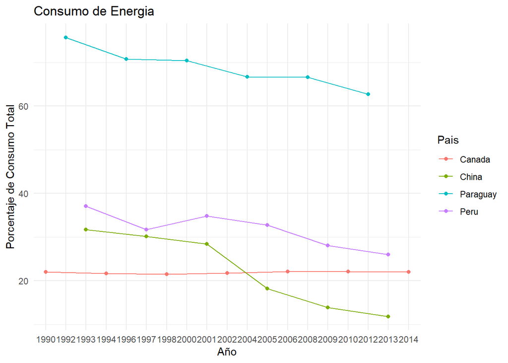

```r
bosques_energia%>%
  filter(Codigo.Pais == c("CAN", "PRY","PER","CHN"))%>%
  ggplot(mapping = aes(x= Anno, y = `Consumo de energía renovable (% del consumo total de energía final)`, group = Pais, color = Pais)) +
  geom_point() +
  geom_line() +
  labs(title = "Consumo de Energia", x = "Año", y = "Porcentaje de Consumo Total")+
  theme_minimal()
```

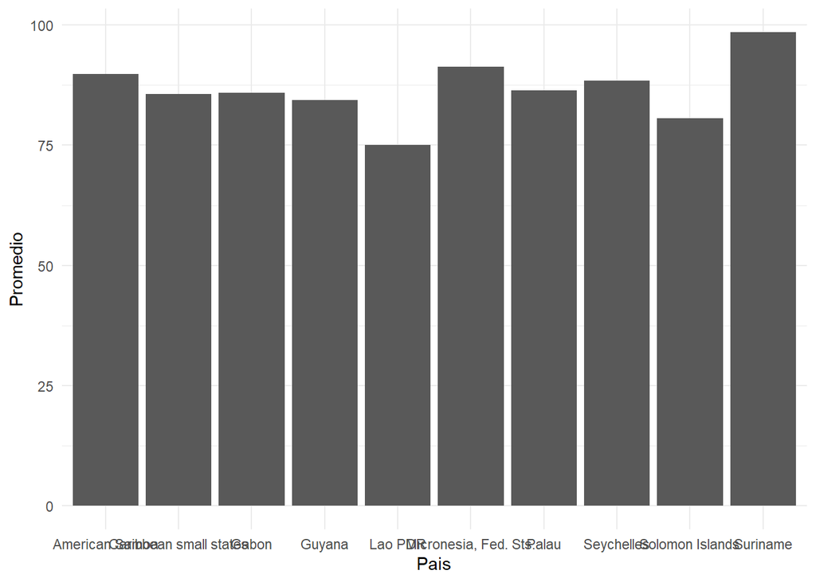

```r
bosques_energia%>%
  group_by(Pais)%>%
  summarise(Promedio = mean(`Superficie forestal (% de la superficie terrestre)`))%>%
  arrange(desc(Promedio))%>%
  head(n = 10) %>%
  ggplot(mapping = aes(x = Pais, y = Promedio)) +
  geom_col() +
  theme_minimal()
```

```r
DatosEducacion <- read.table("DatosTarea1/DatosEducacion.csv", sep = ",")

DatosEducacion <- na.omit(DatosEducacion)


DatosEducacion %>%
  group_by(pais) %>%
  summarise(Promedio = mean(valor))
```

| pais | Promedio |
| --- | --- |
| Afghanistan | 1.646018e+06 |
| Albania | 3.070835e+04 |
| Algeria | 7.431435e+05 |
| American Samoa | 6.000000e+00 |
| Andorra | 2.159182e+01 |
| Angola | 2.399933e+06 |
| Anguilla | 7.000000e+00 |
| Antigua and Barbuda | 2.547109e+03 |
| Argentina | 6.437179e+05 |
| Armenia | 2.441122e+04 |

[output cut: 216 more lines]